# Life Expectancy (Regression Problem)

## Feature selection

Let’s continue with feature selection.

```r
# Remove from the train_set because they provide the same information as Economy_status
train_set$Economy_status_Developing <- NULL
train_set$Economy_status_Developed <- NULL
nrow(train_set)
```

```
## [1] 2327
```

```r
lm.fit <- lm(Life_expectancy ~.-Country, data = train_set)
summary(lm.fit)
```

```
##
## Call:
## lm(formula = Life_expectancy ~ . - Country, data = train_set)
##
## Residuals:
##    Min     1Q Median     3Q    Max
## -80225 -16288  -1467  15094 247246
##
## Coefficients:
##                                       Estimate Std. Error t value Pr(>|t|)
## (Intercept)                          3.262e+05  2.914e+05   1.119 0.263089
## RegionAsia                           1.102e+04  2.284e+03   4.826 1.49e-06 ***
## RegionCentral America and Caribbean  3.263e+04  2.453e+03  13.302  < 2e-16 ***
## RegionEuropean Union                -1.596e+04  3.587e+03  -4.451 8.95e-06 ***
## RegionMiddle East                    1.158e+04  2.811e+03   4.120 3.93e-05 ***
## RegionNorth America                  1.276e+04  4.815e+03   2.650 0.008115 **
## RegionOceania                       -1.133e+04  2.952e+03  -3.838 0.000127 ***
## RegionRest of Europe                 4.734e+03  2.844e+03   1.664 0.096160 .
## RegionSouth America                  2.980e+04  2.798e+03  10.649  < 2e-16 ***
## Year                                 1.158e+02  1.454e+02   0.796 0.426080
## Infant_deaths                       -1.756e+03  1.226e+02 -14.323  < 2e-16 ***
## Under_five_deaths                    1.015e+02  7.742e+01   1.311 0.190151
## Thinness_ten_nineteen_years         -3.794e+02  3.308e+02  -1.147 0.251455
## Thinness_five_nine_years            -2.346e+02  3.246e+02  -0.723 0.469848
## Schooling                            8.875e+02  3.681e+02   2.411 0.015983 *
## Incidents_HIV                        2.298e+03  3.455e+02   6.650 3.64e-11 ***
## Population                          -5.066e-06  4.128e-06  -1.227 0.219785
## GDP                                  7.968e-01  5.006e-02  15.917  < 2e-16 ***
## Economy_statusDeveloping            -5.265e+04  3.323e+03 -15.844  < 2e-16 ***
## Polio                                2.663e+02  1.407e+02   1.893 0.058530 .
## Measles                              4.406e+01  9.459e+01   0.466 0.641403
## Adult_mortality                     -5.454e+02  1.174e+01 -46.451  < 2e-16 ***
## Alcohol                             -6.410e+01  2.306e+02  -0.278 0.781101
## Diphtheria                          -3.293e+02  1.474e+02  -2.233 0.025630 *
## HepatitisB                          -8.643e+02  7.231e+02  -1.195 0.232119
## Mean_BMI                            -1.452e+03  4.625e+02  -3.140 0.001710 **
## ---
## Signif. codes:  0 '***' 0.001 '**' 0.01 '*' 0.05 '.' 0.1 ' ' 1
##
## Residual standard error: 24320 on 2301 degrees of freedom
## Multiple R-squared:  0.962,  Adjusted R-squared:  0.9616
## F-statistic:  2332 on 25 and 2301 DF,  p-value: < 2.2e-16
```

The model’s F-statistic is highly significant, as evidenced by a p-value less than 2.2e-16, indicating that the model as a whole has strong predictive power and at least one of the predictors is statistically significant. Individual t-tests for the coefficients reveal that variables such as RegionAsia, RegionCentral America and Caribbean, Economy_status_Developing, Infant_deaths, and Incidents_HIV, among others, are statistically significant, with p-values well below the conventional alpha level of 0.05. This suggests that these factors have a significant impact on life expectancy. Conversely, variables like Thinness_ten_nineteen_years and Alcohol show a higher p-value, indicating that their relationship with life expectancy is not statistically significant in this model. Because of the large value of predictors we can’t be sure for the results of the t-tests, but the important hypothesis test here is the F-test to make sure that we will be able later to predict Life expectancy using these variables.

First, we use Best subset selection with complexity penalty criterion. Best subset selection can suffer from overfitting when p is large and is computationally expensive when p>30. We have p=25 and n=2327 so n is much greater than p.

```r
n <- 25
bss <- regsubsets(Life_expectancy ~.-Country, data = train_set, nvmax=n)
bss.summary <- summary(bss)
summary(bss)
```

```
## Subset selection object
## Call: regsubsets.formula(Life_expectancy ~ . - Country, data = train_set,
##     nvmax = n)
## 25 Variables  (and intercept)
##                                     Forced in Forced out
## RegionAsia                              FALSE      FALSE
## RegionCentral America and Caribbean     FALSE      FALSE
## RegionEuropean Union                    FALSE      FALSE
## RegionMiddle East                       FALSE      FALSE
## RegionNorth America                     FALSE      FALSE
## RegionOceania                           FALSE      FALSE
## RegionRest of Europe                    FALSE      FALSE
## RegionSouth America                     FALSE      FALSE
## Year                                    FALSE      FALSE
## Infant_deaths                           FALSE      FALSE
```

[output cut: 199 more lines]

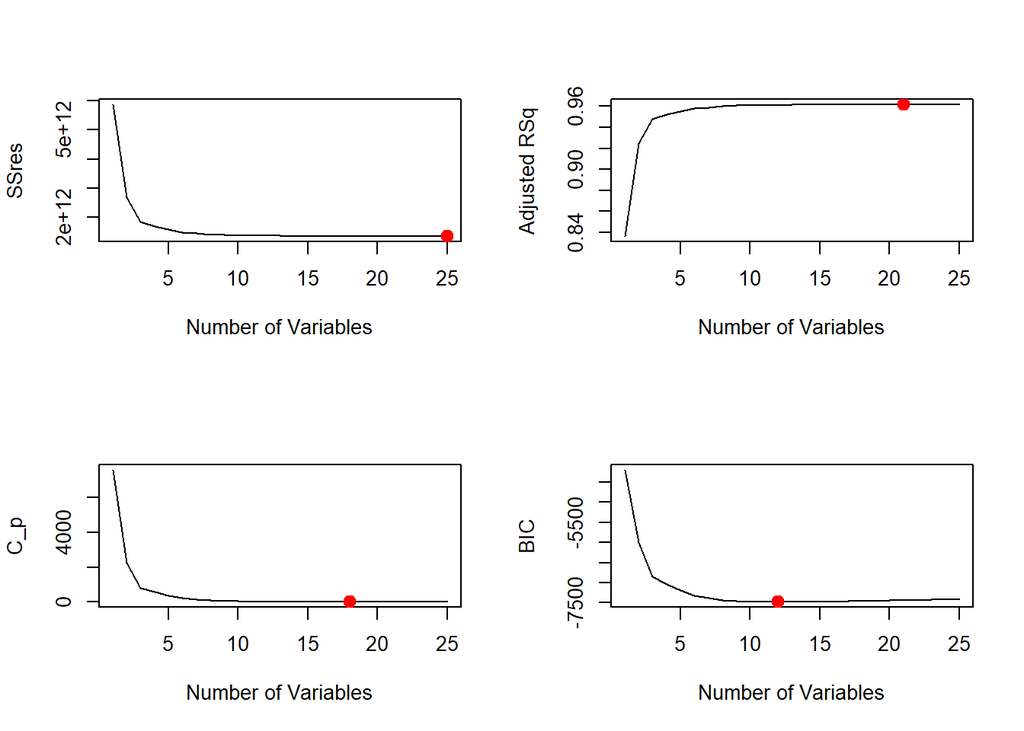

```r
par(mfrow=c(2,2))
plot(bss.summary$rss, xlab="Number of Variables", ylab="SSres", type="l")
K0<-which.min(bss.summary$rss)
points(K0, bss.summary$rss[K0], col="red",cex=2,pch=20)
plot(bss.summary$adjr2,xlab="Number of Variables", ylab="Adjusted RSq", type="l")
K1<-which.max(bss.summary$adjr2)
points(K1, bss.summary$adjr2[K1], col="red",cex=2,pch=20)
plot(bss.summary$cp,xlab="Number of Variables", ylab="C_p", type="l")
K2<-which.min(bss.summary$cp)
points(K2, bss.summary$cp[K2], col="red",cex=2,pch=20)
plot(bss.summary$bic,xlab="Number of Variables", ylab="BIC", type="l")
K3<-which.min(bss.summary$bic)
points(K3, bss.summary$bic[K3], col="red",cex=2,pch=20)
```

```r
coef(bss,12)
```

```
##                         (Intercept)                          RegionAsia
##                        5.320861e+05                        9.779968e+03
## RegionCentral America and Caribbean                RegionEuropean Union
##                        2.861627e+04                       -2.302627e+04
##                   RegionMiddle East                       RegionOceania
##                        6.367688e+03                       -1.754622e+04
##                 RegionSouth America                       Infant_deaths
##                        2.625541e+04                       -1.609299e+03
##         Thinness_ten_nineteen_years                       Incidents_HIV
##                       -6.084190e+02                        1.822458e+03
##                                 GDP            Economy_statusDeveloping
##                        8.364358e-01                       -5.819612e+04
##                     Adult_mortality
##                       -5.327607e+02
```

Predictors for BSS with p=12: Region, Infant_deaths, Incidents_HIV, Thinness_ten_nineteen_years, Economy_status, Adult Mortality and GDP.

```r
coef(bss,8)
```

```
##                         (Intercept) RegionCentral America and Caribbean
##                        5.296906e+05                        2.539597e+04
##                RegionEuropean Union                       RegionOceania
##                       -2.561102e+04                       -1.961341e+04
##                 RegionSouth America                       Infant_deaths
##                        2.375257e+04                       -1.721801e+03
##                                 GDP            Economy_statusDeveloping
##                        8.881116e-01                       -5.716059e+04
##                     Adult_mortality
##                       -5.011660e+02
```

Predictors for BSS with p=8: Region, Infant_deaths, Economy_status, Adult Mortality and GDP.

```r
coef(bss,5)
```

```
##                         (Intercept) RegionCentral America and Caribbean
##                       506263.123852                        23765.039164
##                       Infant_deaths                                 GDP
##                        -1742.248001                            1.013238
##            Economy_statusDeveloping                     Adult_mortality
##                       -32281.926004                         -502.377385
```

Predictors for BSS with p=5: Region, Infant_deaths, Economy_status, Adult Mortality and GDP.

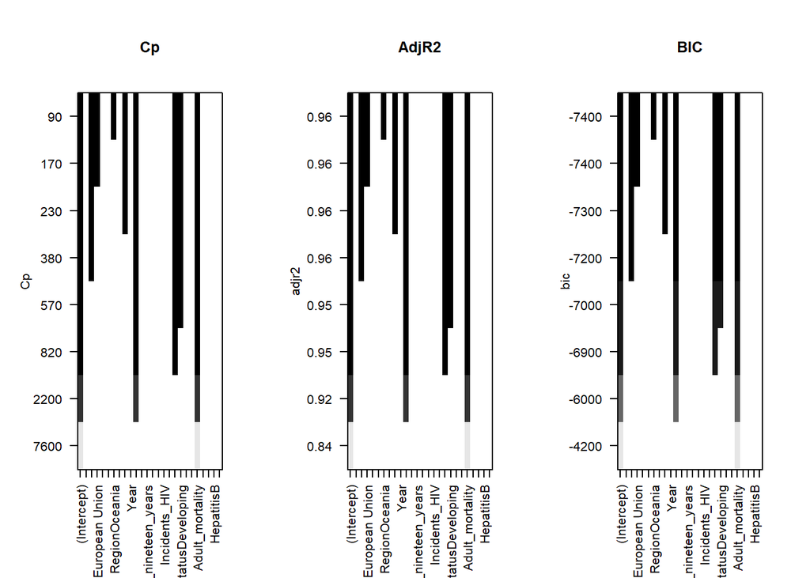

```r
n <- 8
bss <- regsubsets(Life_expectancy ~.-Country, data = train_set, nvmax=n)
bss.summary <- summary(bss)
par(mfrow=c(1,3))
plot(bss, scale = "Cp")
title("Cp")
plot(bss, scale = "adjr2")
title("AdjR2")
plot(bss, scale = "bic")
title("BIC")
```

Let’s try also K-Folds Cross Validation (direct way).

```r
K<-10 # number of folds
q<-25 # number of predictors
set.seed(2)
folds<-sample(1:K, nrow(train_set), replace=TRUE)
cv.errors <- matrix(NA, K, q, dimnames = list(NULL, paste(1:q)))
```

```r
for (j in 1:K) {
  best.fit <- regsubsets(Life_expectancy ~.- Country,
       data = train_set[folds != j, ],
       nvmax = q)
  for (i in 1:q) {
    pred <- predict(best.fit, train_set[folds == j, ], id = i)
    cv.errors[j, i] <- mean((train_set$Life_expectancy[folds == j] - pred)^2)
   }
}
mean.cv.errors<-apply(cv.errors,2,mean)
mean.cv.errors
```

```
##          1          2          3          4          5          6          7
## 2525854579 1164645872  800966838  737024283  689240103  650813985  634642974
##          8          9         10         11         12         13         14
##  614238930  609161317  606815818  602492006  603001185  600094466  604034064
##         15         16         17         18         19         20         21
##  602200800  602492050  599472496  598735647  598741875  598821605  599496576
##         22         23         24         25
##  600276913  599545732  599869702  599747530
```

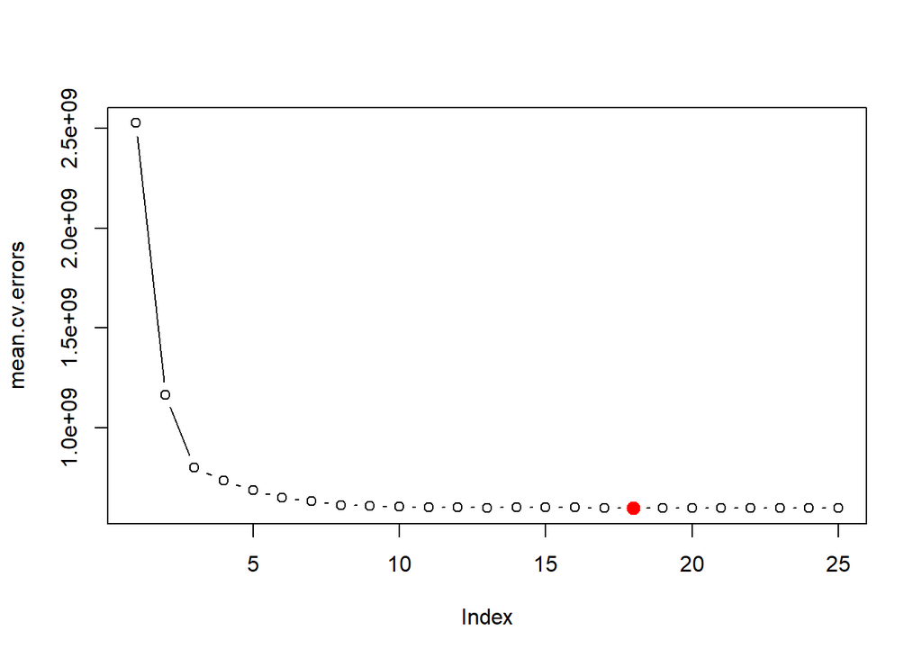

```r
p.cv=which.min(mean.cv.errors)# select model size with minimal mean cv error
plot(mean.cv.errors,type='b')
points(p.cv, mean.cv.errors[p.cv], col="red",cex=2,pch=20)
```

One Standard error rule to find the best model size

```r
SE <- sd(mean.cv.errors)/sqrt(K)
min_mse <- min(mean.cv.errors)
min(which(mean.cv.errors <= SE+min_mse))
```

```
## [1] 5
```

```r
reg.best <- regsubsets(Life_expectancy ~.- Country, data = train_set, nvmax = 25)
coef(reg.best, 5)
```

```
##                         (Intercept) RegionCentral America and Caribbean
##                       506263.123852                        23765.039164
##                       Infant_deaths                                 GDP
##                        -1742.248001                            1.013238
##            Economy_statusDeveloping                     Adult_mortality
##                       -32281.926004                         -502.377385
```

Same 5 predictors like best subset selection. So the 5 predictors will be Region, Infant deaths, Economy status, GDP and Adult Mortality. As we have seen before from the correlations, Adult mortality and infant deaths were high correlated with our response variable. Futhermore, as we have seen in our EDA Region and Economy status were affecting Life expectancy. GDP also was positevely correlated with Life expectancy.

```r
# Remove Country, Economy_status_Developed and Economy_status_Developing
test_set$Country <- NULL
test_set$Economy_status_Developed <- NULL
test_set$Economy_status_Developing <- NULL
# ytest^3 because ypred will be in that form
y.test <- test_set$Life_expectancy^3
```

```r
# Fit the linear model with the above 5 predictors
lm_model <- lm(Life_expectancy ~ Region+Infant_deaths+Economy_status+GDP+Adult_mortality, data = train_set)
lm_pred <- predict(lm_model, newdata = test_set)
sqrt(mean((lm_pred - y.test)^2)) # RMSE
```

```
## [1] 27962.78
```

```r
mean(abs(lm_pred - y.test)) # MAE
```

```
## [1] 22408.43
```

```r
cor(lm_pred, y.test)^2 # R squared
```

```
## [1] 0.9514785
```

### Lasso regression

We will do also a Lasso regression to see which variables stay at the end. We will not perform a Ridge regression as we prefer to have a more interpretable model for our case.

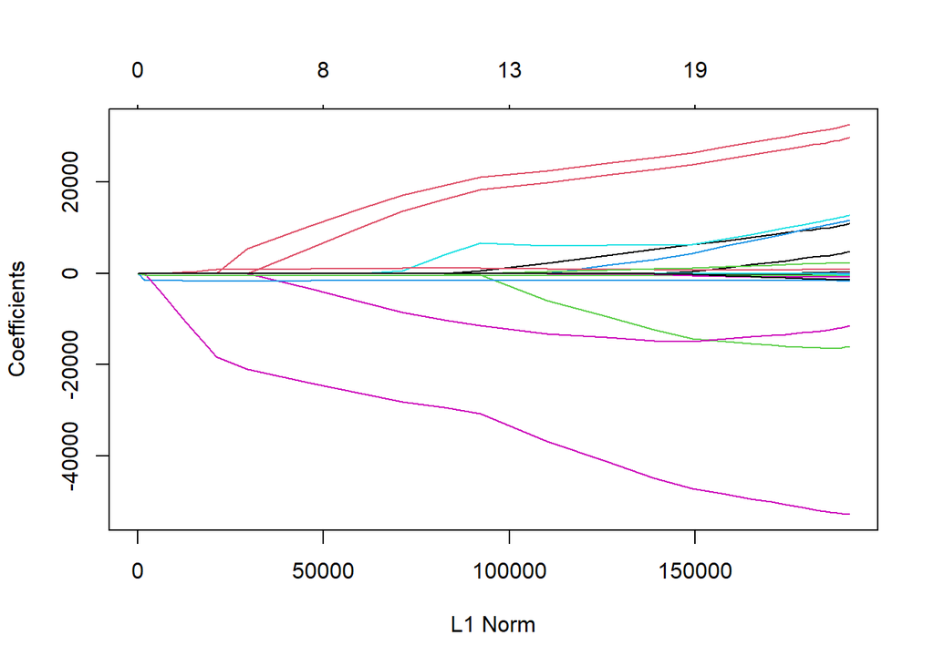

```r
x <- model.matrix(Life_expectancy ~ ., dplyr::select(train_set,-Country))[, -1]
y <- train_set$Life_expectancy
grid <- 10^seq(10, -2, length = 100)
# alpha = 1 for Lasso regression
lasso.mod <- glmnet(x, y, alpha = 1, lambda = grid)
plot(lasso.mod)
```

We can see from the coefficient plot that depending on the choice of tuning parameter, some of the coefficients will be exactly equal to zero. We now perform cross-validation and compute the associated test error.

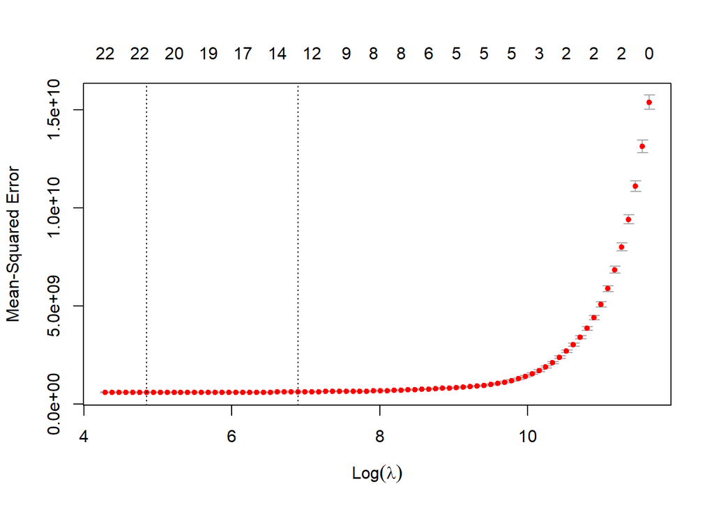

```r
set.seed(1)
cv.out <- cv.glmnet(x, y, alpha = 1, family='gaussian')
plot(cv.out)
```

```r
x.test <- model.matrix(Life_expectancy ~ .,test_set)[, -1]
bestlam <- cv.out$lambda.min
lasso.pred <- predict(lasso.mod, s = bestlam, newx = x.test)
sqrt(mean((lasso.pred - y.test)^2)) # RMSE
```

```
## [1] 27717.51
```

```r
mean(abs(lasso.pred - y.test)) # MAE
```

```
## [1] 22132.62
```

```r
cor(y.test, lasso.pred)^2 # R squared
```

```
##             s1
## [1,] 0.9521488
```

```r
out <- glmnet(x, y, alpha = 1, lambda = grid, family='gaussian'
              )
lasso.coef <- predict(out, type = "coefficients", s = bestlam)[1:25, ]
lasso.coef[lasso.coef != 0]
```

```
##                         (Intercept)                          RegionAsia
##                        5.278817e+05                        8.909546e+03
## RegionCentral America and Caribbean                RegionEuropean Union
##                        2.997735e+04                       -1.601304e+04
##                   RegionMiddle East                 RegionNorth America
##                        8.780311e+03                        1.000955e+04
##                       RegionOceania                RegionRest of Europe
##                       -1.338411e+04                        2.802807e+03
##                 RegionSouth America                                Year
##                        2.721566e+04                        9.656392e+00
##                       Infant_deaths         Thinness_ten_nineteen_years
##                       -1.617635e+03                       -3.220421e+02
##            Thinness_five_nine_years                           Schooling
##                       -2.285291e+02                        7.808958e+02
##                       Incidents_HIV                          Population
##                        1.903934e+03                       -2.979115e-06
##                                 GDP            Economy_statusDeveloping
##                        8.314320e-01                       -5.069382e+04
##                               Polio                     Adult_mortality
##                        4.677973e+00                       -5.358132e+02
##                          Diphtheria                          HepatitisB
##                       -3.308760e+01                       -7.745041e+02
```

We have 21 predictors with non-zero coefficients.

## Random Forest regression

Let’s try to see what results we get if we fit a random Forest regression model, using the 5 important features we found from best subset selection and K-Folds cross-validation.

```r
# Random Forest regression
rf_model <- randomForest(Life_expectancy~Region+Infant_deaths+Economy_status+GDP+Adult_mortality, data = train_set)

# Predict and calculate metrics
rf_pred <- predict(rf_model, newdata = test_set)
sqrt(mean((rf_pred - y.test)^2)) # RMSE
```

```
## [1] 28798.74
```

```r
mean(abs(rf_pred - y.test)) # MAE
```

```
## [1] 22766.24
```

```r
cor(rf_pred, y.test)^2 # R squared
```

```
## [1] 0.9583656
```

## Linear Regression

So we have similar scores when we fitted our model with Linear Regression and Random Forest. Now, we are going to try to improve the linear regression. One of the possible problems that we have already dealt with via feature selection is the multicollinearity (Selection of the 5 most important features).

```r
summary(lm_model)
```

```
##
## Call:
## lm(formula = Life_expectancy ~ Region + Infant_deaths + Economy_status +
##     GDP + Adult_mortality, data = train_set)
##
## Residuals:
##    Min     1Q Median     3Q    Max
## -75895 -16955  -2067  15180 232273
##
## Coefficients:
##                                       Estimate Std. Error t value Pr(>|t|)
## (Intercept)                          5.215e+05  3.919e+03 133.090  < 2e-16 ***
## RegionAsia                           9.098e+03  1.928e+03   4.718 2.52e-06 ***
## RegionCentral America and Caribbean  3.097e+04  2.234e+03  13.863  < 2e-16 ***
## RegionEuropean Union                -1.942e+04  3.369e+03  -5.765 9.26e-09 ***
## RegionMiddle East                    8.010e+03  2.554e+03   3.137  0.00173 **
## RegionNorth America                  9.564e+03  4.586e+03   2.086  0.03711 *
## RegionOceania                       -1.422e+04  2.578e+03  -5.518 3.80e-08 ***
## RegionRest of Europe                 4.438e+03  2.556e+03   1.737  0.08260 .
## RegionSouth America                  2.949e+04  2.561e+03  11.515  < 2e-16 ***
## Infant_deaths                       -1.695e+03  3.366e+01 -50.352  < 2e-16 ***
## Economy_statusDeveloping            -5.761e+04  3.074e+03 -18.741  < 2e-16 ***
## GDP                                  9.011e-01  4.725e-02  19.072  < 2e-16 ***
## Adult_mortality                     -4.874e+02  7.686e+00 -63.414  < 2e-16 ***
## ---
## Signif. codes:  0 '***' 0.001 '**' 0.01 '*' 0.05 '.' 0.1 ' ' 1
##
## Residual standard error: 24630 on 2314 degrees of freedom
## Multiple R-squared:  0.9608, Adjusted R-squared:  0.9606
## F-statistic:  4731 on 12 and 2314 DF,  p-value: < 2.2e-16
```

The model’s adjusted R-squared value of 0.9606, suggesting that the selected features explain a large portion of the variance in life expectancy.

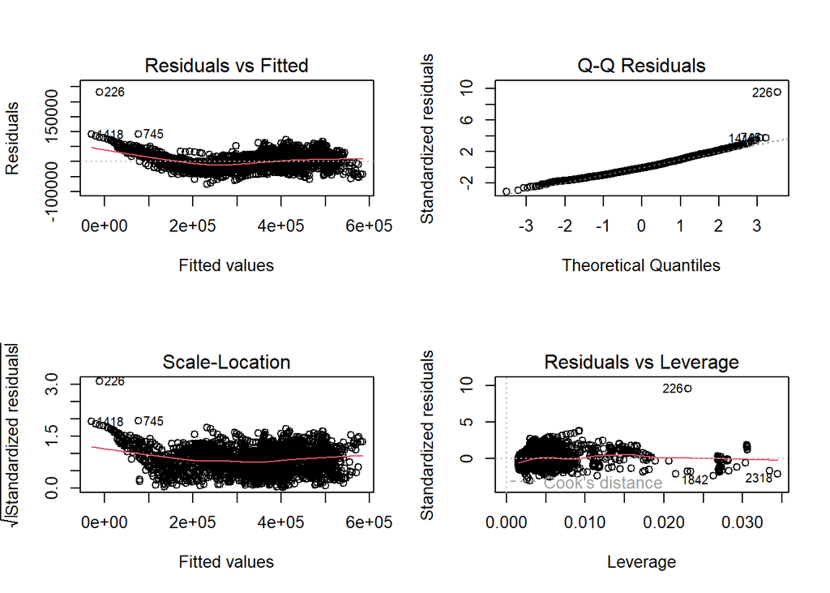

```r
par(mfrow=c(2,2))
plot(lm_model)
```

```r
residuals <- lm_model$residuals
train_set[c(226, 1418, 745), ]
```

```
##              Region     Country Year Infant_deaths Under_five_deaths
## 275  European Union     Croatia 2009           4.9               5.7
## 1769         Africa     Liberia 2008          77.2             108.2
## 948          Africa Gambia, The 2008          48.6              80.3
##      Thinness_ten_nineteen_years Thinness_five_nine_years Schooling
## 275                          1.7                      1.6      10.6
## 1769                         7.7                      7.6       4.0
## 948                          8.6                      8.5       2.6
##      Incidents_HIV Life_expectancy Population        GDP Economy_status Polio
## 275           0.02        442450.7    4305181 14421.1715      Developed    96
## 1769          3.50        197137.4    3783887   456.1447     Developing    79
## 948           1.34        205379.0    1820542   857.8582     Developing    96
##      Measles Adult_mortality Alcohol Diphtheria HepatitisB Mean_BMI
## 275       95             109   11.11         96  0.6774289     26.6
## 1769      76             278    3.90         75 -0.5915787     23.7
## 948       92             283    2.98         96  0.7351110     23.1
```

```r
train_set[c(226, 1842,2318), ]
```

```
##              Region Country Year Infant_deaths Under_five_deaths
## 275  European Union Croatia 2009           4.9               5.7
## 2282         Africa  Zambia 2000          90.2             155.9
## 2853         Africa Nigeria 2012          81.9             131.1
##      Thinness_ten_nineteen_years Thinness_five_nine_years Schooling
## 275                          1.7                      1.6      10.6
## 2282                         7.5                      7.5       5.9
## 2853                         1.7                      1.6       5.7
##      Incidents_HIV Life_expectancy Population        GDP Economy_status Polio
## 275           0.02        442450.7    4305181 14421.1715      Developed    96
## 2282          9.75         85184.0    9891136   364.0261     Developing    85
## 2853          0.70        138991.8  170075932  2728.0228     Developing    42
##      Measles Adult_mortality Alcohol Diphtheria HepatitisB Mean_BMI
## 275       95             109   11.11         96  0.6774289     26.6
## 2282      85             594    2.82         85  0.2159716     21.5
## 2853      42             373    4.73         42 -2.4950899     23.1
```

Cook’s Distance: The dashed Cook’s distance lines suggest cutoffs for what might be considered an influential point.

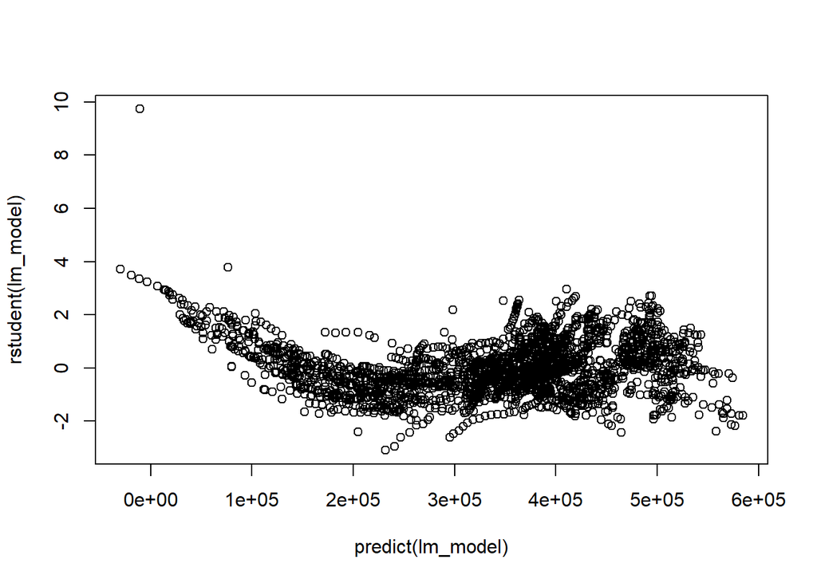

```r
plot(predict(lm_model), rstudent(lm_model))
```

```r
studentized_residuals <- rstudent(lm_model)
# Find the indices of the observations where the absolute value of studentized residuals is greater than 3
extreme_residuals <- which(abs(studentized_residuals) > 2)
# Get the row names of those extreme residuals
extreme_residuals <- row.names(df)[extreme_residuals]
extreme_residuals_row_numbers <- as.numeric(extreme_residuals)
extreme_residuals_points <- data.frame(Row = extreme_residuals_row_numbers, StudentizedResiduals = studentized_residuals[extreme_residuals])

extreme_residuals <- which(abs(studentized_residuals) > 3)
# Get the row names of those extreme residuals
extreme_residuals <- row.names(df)[extreme_residuals]
extreme_residuals_row_numbers <- as.numeric(extreme_residuals)
extreme_residuals_points2 <- data.frame(Row = extreme_residuals_row_numbers, StudentizedResiduals = studentized_residuals[extreme_residuals])
```

```r
leverage_values <- hatvalues(lm_model)

top_indices <- which(leverage_values > 0.020)
# Get the row names of the top high leverage points
top_indices <- row.names(df)[top_indices]
top_row_numbers <- as.numeric(top_indices)
top_leverage_values <- leverage_values[top_indices]
top_rows_and_leverage <- data.frame(Row = top_row_numbers, Leverage = top_leverage_values)
```

```r
# Train set 1 has removed high leverage points and removed outliers where studentized residuals >2
train_set1 <- train_set[-top_rows_and_leverage$Row, ]
train_set1 <- train_set1[-extreme_residuals_points$Row,]

# Train set 2 has removed high leverage points and removed outliers where studentized residuals >3
train_set2 <- train_set[-top_rows_and_leverage$Row, ]
train_set2 <- train_set2[-extreme_residuals_points2$Row,]
```

Another important assumption of linear regression is the linearity of the response-predictors relationship. As we have seen previously on our EDA we may improve our model if we log transform the predictors of Adult mortality and GDP. Below we can see the graphs of our response with each of these predictors (with log transformation).

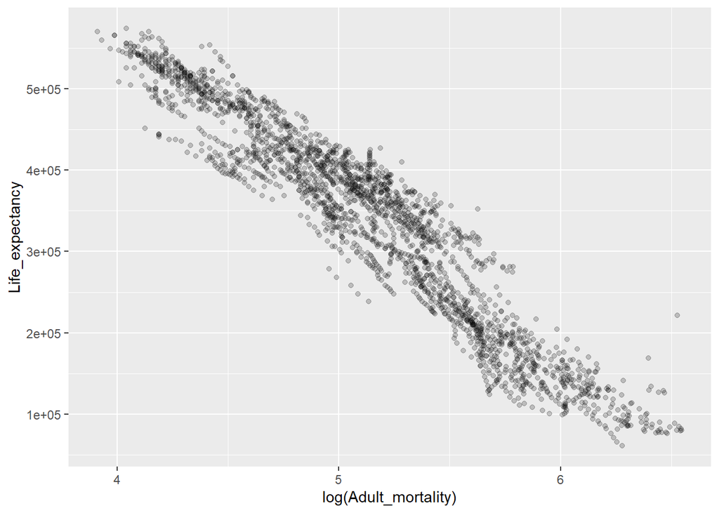

```r
# Check the relationship between the response and the predictors
ggplot(data = train_set) + geom_point(mapping = aes(x = log(Adult_mortality), y = Life_expectancy),
                                        alpha = 1 / 5)
```

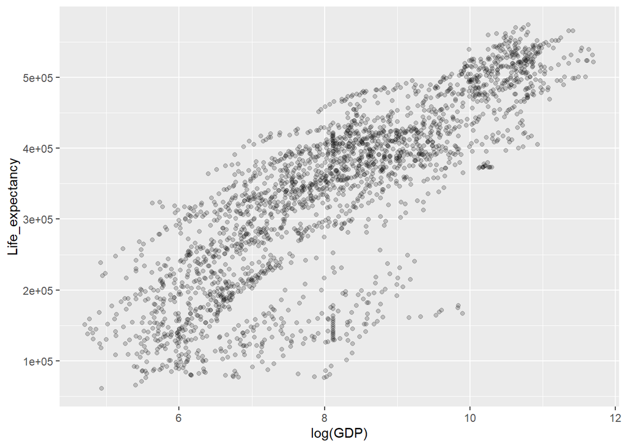

```r
ggplot(data = train_set) + geom_point(mapping = aes(x = log(GDP), y = Life_expectancy),
                                        alpha = 1 / 5)
```

Indeed we see that we have an improvement of the linearity of these 2 relationships. So we hope to get better results if we fit our model taking that into account.

```r
# Fit the linear model with log(Adult mortality) and log(GDP)
lm_model <- lm(Life_expectancy ~ Region+Infant_deaths+Economy_status +log(GDP)+log(Adult_mortality), data = train_set)
lm_pred <- predict(lm_model, newdata = test_set)
sqrt(mean((lm_pred - y.test)^2)) # RMSE
```

```
## [1] 21600.57
```

```r
mean(abs(lm_pred - y.test)) # MAE
```

```
## [1] 16161.29
```

```r
cor(lm_pred, y.test)^2 # R squared
```

```
## [1] 0.9668497
```

We see an improvement on the metrics calculated on unseen data! So for now that’s the best model we have. Next, we check the optimal complexity of Infant deaths for our model.

```r
set.seed(17)  # for reproducibility
# Prepare a data frame to store CV errors for different polynomial degrees
cv.error <- data.frame(degree = integer(), CV_MSE = numeric())

# Loop through degrees 1 to 10 for the polynomial
for (degree in 1:10) {
  # Fit model with a polynomial term for Infant_deaths
  # Perform linear regression using the glm() function rather than the lm() function because the former can
  # be used together with cv.glm()
  glm.fit <- glm(Life_expectancy ~ Region + poly(Infant_deaths, degree) +
                  Economy_status + log(GDP) + log(Adult_mortality),
                data = train_set)
  # Perform 10-fold CV
  cv.error[degree, "degree"] <- degree
  # cv.glm Boot library
  cv.error[degree, "CV_MSE"] <- cv.glm(train_set, glm.fit, K = 10)$delta[1]
}
# View the cross-validation errors
print(cv.error)
```

```
##    degree    CV_MSE
## 1       1 359216093
## 2       2 319646591
## 3       3 319276551
## 4       4 319114173
## 5       5 318862248
## 6       6 316194365
## 7       7 317536661
## 8       8 309993079
## 9       9 304375279
## 10     10 305533236
```

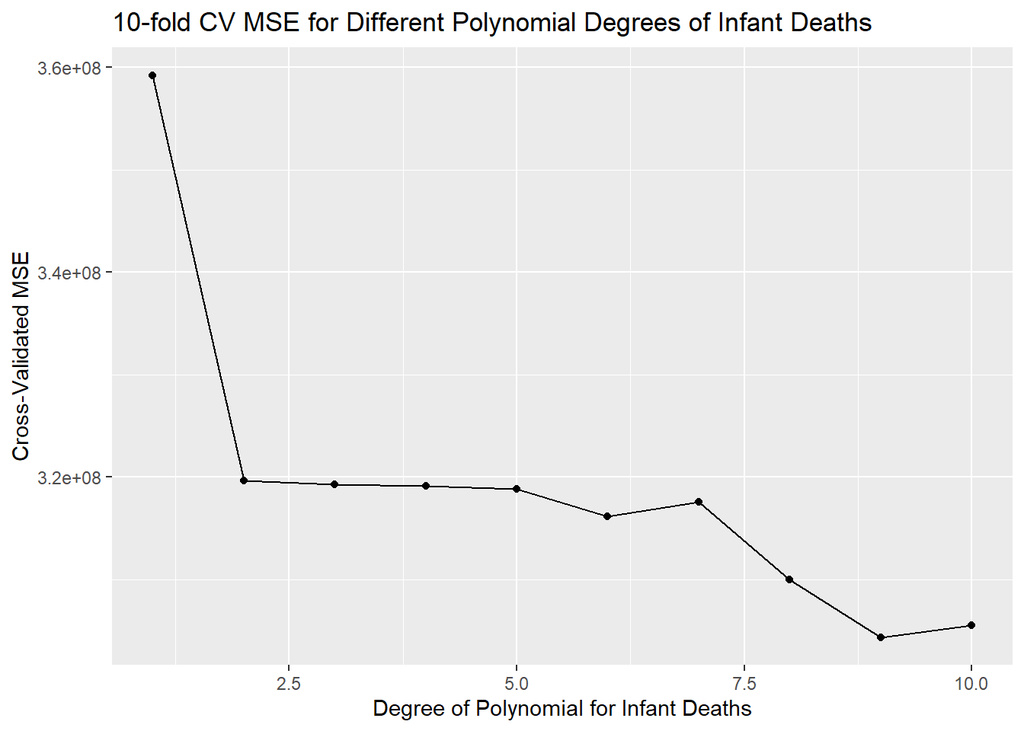

```r
# Plot the CV errors
ggplot(cv.error, aes(x = degree, y = CV_MSE)) +
  geom_line() + geom_point() +
  labs(x = "Degree of Polynomial for Infant Deaths", y = "Cross-Validated MSE") +
  ggtitle("10-fold CV MSE for Different Polynomial Degrees of Infant Deaths")
```

```r
lm.fit <- lm(Life_expectancy ~ Region + Infant_deaths+Economy_status +
                 log(GDP)+log(Adult_mortality), data = train_set)
lm.fit2 <- lm(Life_expectancy ~ Region + poly(Infant_deaths, 2)+Economy_status +
                 log(GDP)+log(Adult_mortality), data = train_set)
anova(lm.fit, lm.fit2)
```

```
## Analysis of Variance Table
##
## Model 1: Life_expectancy ~ Region + Infant_deaths + Economy_status + log(GDP) +
##     log(Adult_mortality)
## Model 2: Life_expectancy ~ Region + poly(Infant_deaths, 2) + Economy_status +
##     log(GDP) + log(Adult_mortality)
##   Res.Df        RSS Df  Sum of Sq     F    Pr(>F)
## 1   2314 8.2527e+11
## 2   2313 7.3421e+11  1 9.1069e+10 286.9 < 2.2e-16 ***
## ---
## Signif. codes:  0 '***' 0.001 '**' 0.01 '*' 0.05 '.' 0.1 ' ' 1
```

The anova() function performs a hypothesis test comparing the two models. The null hypothesis is that the two models fit the data equally well, and the alternative hypothesis is that the full model is superior. Here the F-statistic is 286.9 and the associated p-value is virtually zero. This provides very clear evidence that the model containing the predictors Infant_deaths and $Infant\_deaths^2$ is far superior to the model that only contains the predictor Infant_deaths.

```r
lm.fit3 <- lm(Life_expectancy ~ Region + poly(Infant_deaths, 3)+Economy_status +
                 log(GDP)+log(Adult_mortality), data = train_set)
anova(lm.fit2, lm.fit3)
```

```
## Analysis of Variance Table
##
## Model 1: Life_expectancy ~ Region + poly(Infant_deaths, 2) + Economy_status +
##     log(GDP) + log(Adult_mortality)
## Model 2: Life_expectancy ~ Region + poly(Infant_deaths, 3) + Economy_status +
##     log(GDP) + log(Adult_mortality)
##   Res.Df        RSS Df Sum of Sq      F Pr(>F)
## 1   2313 7.3421e+11
## 2   2312 7.3368e+11  1 527784278 1.6632 0.1973
```

Here the F-statistic is 1.6632 and the associated p-value is greater than 0.05 ($\alpha=0.05$ significance level). We do not reject the Null Hypothesis and this means that the two models fit the data equally well. Thus, the best model is with $Infant\_deaths^2$.

```r
lm_model <- lm(Life_expectancy ~ Region + poly(Infant_deaths, 2)+Economy_status +
                 log(GDP)+log(Adult_mortality), data = train_set)
lm_pred <- predict(lm_model, newdata = test_set)
sqrt(mean((lm_pred - y.test)^2)) # RMSE
```

```
## [1] 21195.52
```

```r
mean(abs(lm_pred - y.test)) # MAE
```

```
## [1] 15885.05
```

```r
cor(lm_pred, y.test)^2 # R squared
```

```
## [1] 0.9683997
```

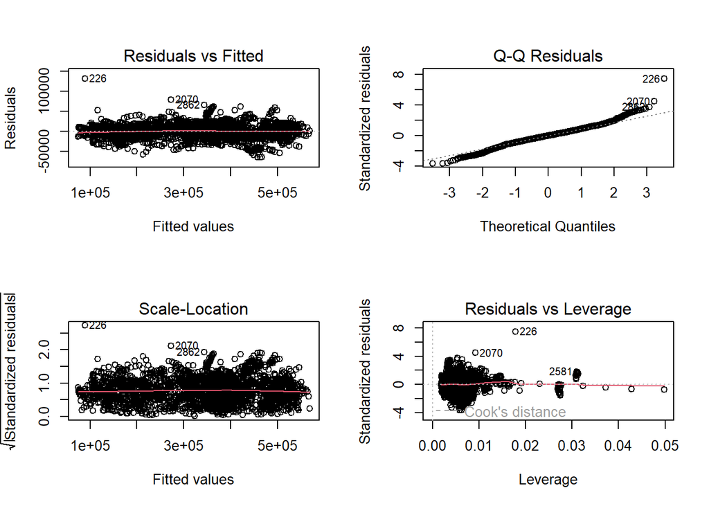

```r
par(mfrow=c(2,2))
plot(lm_model)
```

The diagnostic plots indicate moderate improvements in the regression model’s assumptions. The Residuals vs Fitted and Scale-Location plots suggest a slight reduction in non-linearity and heteroscedasticity, indicating better compliance with the assumptions of equal variance and linearity. The Q-Q plot shows a better alignment of residuals with the normal distribution, although deviations at the tails persist, suggesting the presence of outliers.

The bootstrap approach can be used to assess the variability of the coefficient estimates and predictions from a statistical learning method.

```r
boot.fn <- function(data, index){
  coef(lm(Life_expectancy ~ Region + poly(Infant_deaths, 2)+Economy_status +
                 log(GDP)+log(Adult_mortality), data = data, subset = index))
}
set.seed(1)
boot(train_set, boot.fn, 1000)
```

```
##
## ORDINARY NONPARAMETRIC BOOTSTRAP
##
##
## Call:
## boot(data = train_set, statistic = boot.fn, R = 1000)
##
##
## Bootstrap Statistics :
##           original      bias    std. error
## t1*   9.897604e+05 -400.878282  10209.4647
## t2*   1.619756e+04   64.090159   1458.1152
## t3*   3.828896e+04   -5.901981   2157.7485
## t4*  -4.847519e+03  104.817120   2160.6409
## t5*   5.297867e+02   26.263695   2489.5517
## t6*   2.530050e+04   51.791023   3806.1180
## t7*  -5.013911e+03  -79.536726   2203.5634
## t8*   4.066274e+03  122.239785   1919.7969
## t9*   3.424865e+04   74.623959   1700.5248
## t10* -2.340485e+06 1333.044572  50010.2154
## t11*  4.131712e+05 -805.522316  23290.4293
## t12* -2.858135e+04    4.438123   1913.2789
## t13*  4.425490e+00   15.190340    555.8683
## t14* -1.241373e+05   42.609658   1491.6040
```

```r
summary(lm(Life_expectancy ~ Region + poly(Infant_deaths, 2)+Economy_status+
                 log(GDP)+log(Adult_mortality), data = train_set))$coef
```

```
##                                          Estimate Std. Error       t value
## (Intercept)                          9.897604e+05  9220.9801 107.337875799
## RegionAsia                           1.619756e+04  1399.3967  11.574675293
## RegionCentral America and Caribbean  3.828896e+04  1599.3726  23.939988192
## RegionEuropean Union                -4.847519e+03  2442.0790  -1.984996829
## RegionMiddle East                    5.297867e+02  1851.6111   0.286122020
## RegionNorth America                  2.530050e+04  3301.7948   7.662650663
## RegionOceania                       -5.013911e+03  1857.2134  -2.699695795
## RegionRest of Europe                 4.066274e+03  1943.0865   2.092687909
## RegionSouth America                  3.424865e+04  1833.8277  18.676048650
## poly(Infant_deaths, 2)1             -2.340485e+06 45508.8268 -51.429252169
## poly(Infant_deaths, 2)2              4.131712e+05 24393.0259  16.938088707
## Economy_statusDeveloping            -2.858135e+04  2159.5661 -13.234764130
## log(GDP)                             4.425490e+00   517.9888   0.008543601
## log(Adult_mortality)                -1.241373e+05  1356.8241 -91.491102311
##                                          Pr(>|t|)
## (Intercept)                          0.000000e+00
## RegionAsia                           3.688790e-30
## RegionCentral America and Caribbean 2.427116e-113
## RegionEuropean Union                 4.726277e-02
## RegionMiddle East                    7.748103e-01
## RegionNorth America                  2.660348e-14
## RegionOceania                        6.990820e-03
## RegionRest of Europe                 3.648574e-02
## RegionSouth America                  1.301967e-72
## poly(Infant_deaths, 2)1              0.000000e+00
## poly(Infant_deaths, 2)2              9.308988e-61
## Economy_statusDeveloping             1.347881e-38
## log(GDP)                             9.931840e-01
## log(Adult_mortality)                 0.000000e+00
```

Comparing the bootstrap results with the original regression output, we see that for most coefficients, the bootstrap standard errors are reasonably close to the original standard errors, which suggests that the model estimates are relatively stable. However, the coefficients have some bias according to the bootstrap results, which could warrant further investigation.

The relationship between a country’s wealth (GDP) and its adult mortality rates could be non-linear or might change at different levels of GDP. We will include an interaction term between them to check if we will get better results.

```r
lm_model <- lm(Life_expectancy ~ Region + poly(Infant_deaths, 2)+Economy_status
                 +log(GDP)*log(Adult_mortality), data = train_set)
lm_pred <- predict(lm_model, newdata = test_set)
sqrt(mean((lm_pred - y.test)^2)) # RMSE
```

```
## [1] 21245.88
```

```r
mean(abs(lm_pred - y.test)) # MAE
```

```
## [1] 15969.35
```

```r
cor(lm_pred, y.test)^2 # R squared
```

```
## [1] 0.9682709
```

With including an interaction term the metrics on unseen data are slightly worse. Thus, our best model is without an interaction term. Now we want to train our model with the two sets that we created above where we removed outliers and high leverage points.

Note: After removing the outliers and the high leverages all entries of North America had been removed. Because of that there was an error because the model couldn’t train for North America, but the test set had values of North America. We replace the values from North America to South America in order to work. So the following two models are not comparable with the previous models.

```r
train_set1$Region <-as.factor(train_set1$Region)

test_set$Region <- as.factor(ifelse(test_set$Region == "North America", "South America", as.character(test_set$Region)))

# Train set 1 has removed high leverage points and removed outliers where studentized residuals >2
lm_model1 <- lm(Life_expectancy ~ Region + poly(Infant_deaths, 2)+Economy_status +
                log(GDP)+log(Adult_mortality), data = train_set1)
lm_pred <- predict(lm_model1, newdata = test_set)
sqrt(mean((lm_pred - y.test)^2)) # RMSE
```

```
## [1] 21179.7
```

```r
mean(abs(lm_pred - y.test)) # MAE
```

```
## [1] 15942.99
```

```r
cor(lm_pred, y.test)^2 # R squared
```

```
## [1] 0.9683578
```

```r
# Train set 2 has removed high leverage points and removed outliers where studentized residuals >3
lm_model2 <- lm(Life_expectancy ~ Region + poly(Infant_deaths, 2)+Economy_status +
                log(GDP)+log(Adult_mortality), data = train_set2)
lm_pred <- predict(lm_model2, newdata = test_set)
sqrt(mean((lm_pred - y.test)^2)) # RMSE
```

```
## [1] 21210.37
```

```r
mean(abs(lm_pred - y.test)) # MAE
```

```
## [1] 15966.01
```

```r
cor(lm_pred, y.test)^2 # R squared
```

```
## [1] 0.9683187
```

Cyprus Life expectancy 2000 - 2015

```r
life_data[life_data$Country == 'Cyprus', ]$Life_expectancy
```

```
##  [1] 78.8 78.4 78.0 79.4 78.5 79.2 79.6 78.1 78.6 78.3 78.9 79.8 79.1 80.2 80.0
## [16] 80.4
```

```r
best_model <- lm(Life_expectancy ~ Region + poly(Infant_deaths, 2)+Economy_status +
                 log(GDP)+log(Adult_mortality), data = train_set)
```

The equation of the best model is $\hat{Life\_expectancy}^3 = \hat{\beta}_0 + \hat{\beta}_1 \cdot \text{Asia} + \hat{\beta}_2 \cdot \text{Central America and Caribbean} + \hat{\beta}_3 \cdot \text{European Union} + \hat{\beta}_4 \cdot \text{Middle East} \\+ \hat{\beta}_5 \cdot \text{North America} + \hat{\beta}_6 \cdot \text{Oceania} + \hat{\beta}_7 \cdot \text{Rest of Europe} + \hat{\beta}_8 \cdot \text{South America} + \hat{\beta}_9 \cdot \text{Infant_deaths} \\ + \hat{\beta}_{10} \cdot \text{Infant_deaths}^2 + \hat{\beta}_{11} \cdot \text{Economy_status Developing} + \hat{\beta}_{12} \cdot \log(\text{GDP}) + \hat{\beta}_{13} \cdot \log(\text{Adult_mortality})$

Please note that in the regression model for forecasting life expectancy within the Africa Region, all regional predictors are set to 0. Same for predicting Life Excpectancy for Developed countries the Economy_statusDeveloping is set to 0.

The coefficients of the best model.

```r
coef(best_model)
```

```
##                         (Intercept)                          RegionAsia
##                        9.897604e+05                        1.619756e+04
## RegionCentral America and Caribbean                RegionEuropean Union
##                        3.828896e+04                       -4.847519e+03
##                   RegionMiddle East                 RegionNorth America
##                        5.297867e+02                        2.530050e+04
##                       RegionOceania                RegionRest of Europe
##                       -5.013911e+03                        4.066274e+03
##                 RegionSouth America             poly(Infant_deaths, 2)1
##                        3.424865e+04                       -2.340485e+06
##             poly(Infant_deaths, 2)2            Economy_statusDeveloping
##                        4.131712e+05                       -2.858135e+04
##                            log(GDP)                log(Adult_mortality)
##                        4.425490e+00                       -1.241373e+05
```

In 2020, adult mortality rate for Cyprus was 9.18 deaths per 100 population (COVID 19). Below we can see the prediction interval and the prediction of Life Expectancy for the following values of predictors: `Adult_mortality` = 91.8, `Country` = Cyprus, `Region` = European Union, `GDP` = 32000, `Infant_deaths` = 3.2 and `Economy_status` = Developed country.

```r
newdata <- data.frame(Region = 'European Union', Country = 'Cyprus', Infant_deaths = 3.2, Economy_status = 'Developed', GDP = 32000, Adult_mortality = 91.8)
predictions <- predict(best_model, newdata, interval="prediction", level =0.95)

fit <- predictions[, "fit"]
lwr <- predictions[, "lwr"]
upr <- predictions[, "upr"]

# To take the cube root to get back to the original Life_expectancy scale
fit_original <- fit^(1/3)
lwr_original <- lwr^(1/3)
upr_original <- upr^(1/3)

# Print the original life expectancy and its prediction interval
data.frame(Life_expectancy = fit_original, Lower_Bound = lwr_original, Upper_Bound = upr_original)
```

```
##   Life_expectancy Lower_Bound Upper_Bound
## 1        78.36542    76.41824    80.22037
```

The 95% prediction interval is approximately (76.4, 80.2)